# STAT 479: Causal Inference – Visual Study Guide

Midterm Review (Weeks 1-7)

March 2026

# How to Use This

Knit this document (`Ctrl+Shift+K` in RStudio) to get an HTML page with all the plots rendered. Every code chunk is fully commented so you can see exactly what is being computed and plotted. The visuals match the concepts in the written study guide – work through both side by side.

# 1. The Fundamental Problem of Causal Inference

We can never observe both potential outcomes for the same person. This plot shows a toy population where we pretend to know both Y(1) and Y(0), then shows what we actually get to see.

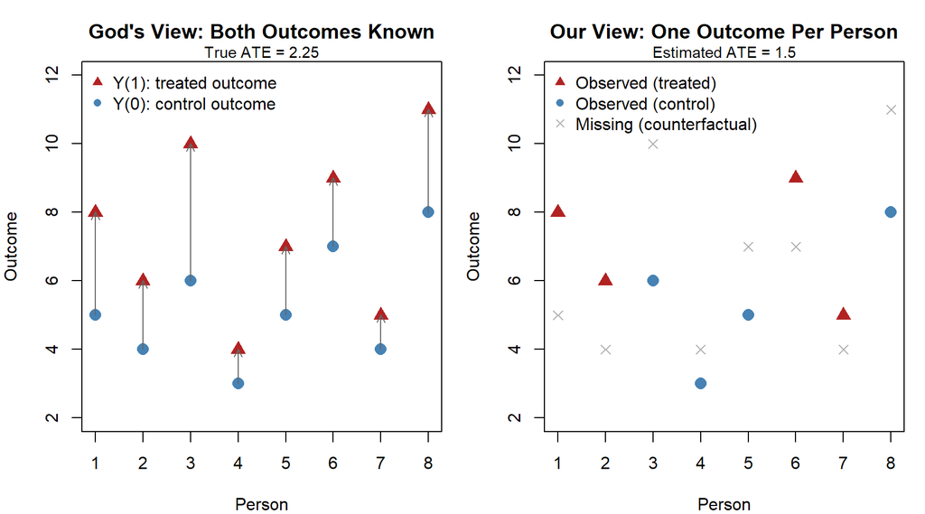

```r
# ----- Build a toy population of 8 people -----
n <- 8
people <- data.frame(
  id    = 1:n,
  Y1    = c(8, 6, 10, 4, 7, 9, 5, 11),   # potential outcome if treated
  Y0    = c(5, 4, 6, 3, 5, 7, 4, 8),      # potential outcome if NOT treated
  tau   = NA                                # individual treatment effect
)
people$tau <- people$Y1 - people$Y0  # true individual effect

# ----- Randomly assign 4 to treatment -----
treated_ids <- sample(1:n, 4)
people$Z <- ifelse(people$id %in% treated_ids, 1, 0)

# What we actually observe: Y(1) if treated, Y(0) if control
people$Y_obs <- ifelse(people$Z == 1, people$Y1, people$Y0)

# What we CANNOT see (the counterfactual)
people$Y_missing <- ifelse(people$Z == 1, people$Y0, people$Y1)

# ----- Plot: what God sees vs what we see -----
par(mfrow = c(1, 2), mar = c(4, 4, 3, 1))

# Left panel: GOD'S VIEW -- both potential outcomes
plot(1:n, people$Y1, pch = 17, col = "firebrick", cex = 1.5, ylim = c(2, 12),
     xlab = "Person", ylab = "Outcome", main = "God's View: Both Outcomes Known")
points(1:n, people$Y0, pch = 16, col = "steelblue", cex = 1.5)
# draw arrows showing the treatment effect for each person
arrows(1:n, people$Y0, 1:n, people$Y1, length = 0.08, col = "gray40")
legend("topleft", legend = c("Y(1): treated outcome", "Y(0): control outcome"),
       pch = c(17, 16), col = c("firebrick", "steelblue"), bty = "n")
mtext(paste("True ATE =", round(mean(people$tau), 2)), side = 3, line = 0, cex = 0.9)

# Right panel: RESEARCHER'S VIEW -- only observe one outcome per person
plot(1:n, people$Y_obs, pch = ifelse(people$Z == 1, 17, 16),
     col = ifelse(people$Z == 1, "firebrick", "steelblue"),
     cex = 1.5, ylim = c(2, 12),
     xlab = "Person", ylab = "Outcome", main = "Our View: One Outcome Per Person")
# show the missing outcome as a faded '?'
points(1:n, people$Y_missing, pch = 4, col = "gray70", cex = 1.2)
legend("topleft",
       legend = c("Observed (treated)", "Observed (control)", "Missing (counterfactual)"),
       pch = c(17, 16, 4), col = c("firebrick", "steelblue", "gray70"), bty = "n")
tau_hat <- mean(people$Y_obs[people$Z == 1]) - mean(people$Y_obs[people$Z == 0])
mtext(paste("Estimated ATE =", round(tau_hat, 2)), side = 3, line = 0, cex = 0.9)
```

**Takeaway:** The left panel is what we wish we had. The right panel is reality. The gray X’s are the counterfactual outcomes we never get to see. Our estimate bounces around the true ATE depending on which randomization we happened to get.

# 2. Unbiasedness: Many Randomizations, One True Answer

If we repeat the experiment many times (re-randomize each time), the average of all our estimates equals the true ATE. That is unbiasedness.

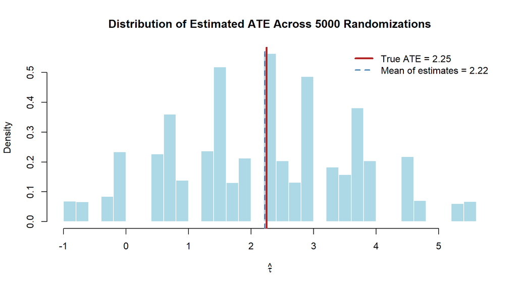

```r
# ----- Same 8 people, but now repeat the experiment 5000 times -----
n <- 8
Y1 <- c(8, 6, 10, 4, 7, 9, 5, 11)
Y0 <- c(5, 4, 6,  3, 5, 7, 4, 8)
true_ate <- mean(Y1 - Y0)

n_sims <- 5000
estimates <- numeric(n_sims)

for (s in 1:n_sims) {
  # each time, randomly pick 4 people for treatment
  Z <- rep(0, n)
  Z[sample(1:n, 4)] <- 1
  # observe outcomes based on assignment
  Y_obs <- ifelse(Z == 1, Y1, Y0)
  # compute the difference-in-means estimate
  estimates[s] <- mean(Y_obs[Z == 1]) - mean(Y_obs[Z == 0])
}

# ----- Histogram of estimates across all randomizations -----
hist(estimates, breaks = 30, col = "lightblue", border = "white",
     main = "Distribution of Estimated ATE Across 5000 Randomizations",
     xlab = expression(hat(tau)), probability = TRUE)
abline(v = true_ate, col = "firebrick", lwd = 3, lty = 1)
abline(v = mean(estimates), col = "steelblue", lwd = 2, lty = 2)
legend("topright",
       legend = c(
         paste("True ATE =", round(true_ate, 2)),
         paste("Mean of estimates =", round(mean(estimates), 2))
       ),
       col = c("firebrick", "steelblue"), lwd = c(3, 2), lty = c(1, 2), bty = "n")
```

**Takeaway:** Each individual estimate (one bar in the histogram) can be too high or too low. But the CENTER of the distribution lands on the true ATE. That is what “unbiased” means – on average, across randomizations, you get it right.

# 3. Neyman Variance: Why the Conservative Estimator Overestimates

The exact variance has a $-S_\tau^2/N$ term. The conservative estimator drops it. This shows the gap between the two.

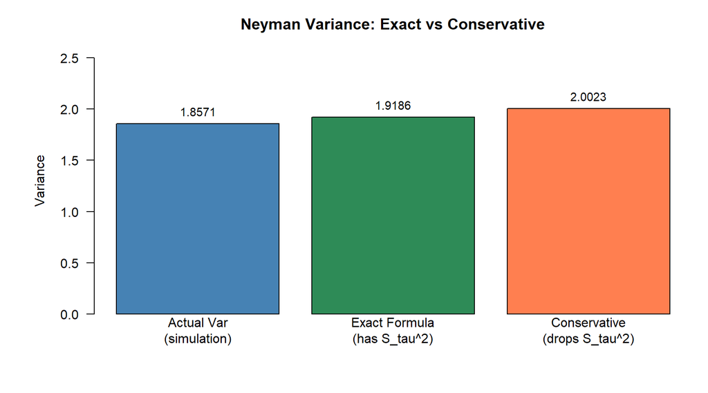

```r
# ----- Create a population with heterogeneous treatment effects -----
N <- 200
Y0_pop <- rnorm(N, mean = 50, sd = 10)

# heterogeneous effects: some people benefit a lot, some a little
tau_pop <- rnorm(N, mean = 5, sd = 4)  # S_tau^2 is large (sd=4)
Y1_pop <- Y0_pop + tau_pop

true_ate <- mean(tau_pop)

# compute population quantities
S1_sq <- var(Y1_pop)  # variance of treated potential outcomes (over all N)
S0_sq <- var(Y0_pop)  # variance of control potential outcomes
S_tau_sq <- var(tau_pop)  # treatment effect heterogeneity

n1 <- 100; n0 <- 100  # balanced design

exact_var    <- S1_sq / n1 + S0_sq / n0 - S_tau_sq / N
conserv_var  <- S1_sq / n1 + S0_sq / n0

# ----- Now simulate to confirm -----
n_sims <- 5000
ests <- numeric(n_sims)
var_ests <- numeric(n_sims)  # conservative variance estimates

for (s in 1:n_sims) {
  idx_t <- sample(1:N, n1)
  Z <- rep(0, N); Z[idx_t] <- 1
  Y_obs <- ifelse(Z == 1, Y1_pop, Y0_pop)
  ests[s] <- mean(Y_obs[Z == 1]) - mean(Y_obs[Z == 0])
  # conservative variance estimate (what you compute on the exam)
  s1 <- var(Y_obs[Z == 1])
  s0 <- var(Y_obs[Z == 0])
  var_ests[s] <- s1 / n1 + s0 / n0
}

# ----- Bar chart comparing exact vs conservative vs empirical -----
par(mar = c(5, 6, 3, 1))
vals <- c(var(ests), exact_var, mean(var_ests))
names(vals) <- c("Actual Var\n(simulation)", "Exact Formula\n(has S_tau^2)", "Conservative\n(drops S_tau^2)")
bp <- barplot(vals, col = c("steelblue", "seagreen", "coral"),
        main = "Neyman Variance: Exact vs Conservative",
        ylab = "Variance", las = 1, ylim = c(0, max(vals) * 1.3))
text(bp, vals, labels = round(vals, 4), pos = 3, cex = 0.9)
```

**Takeaway:** The coral bar (conservative) is always taller than the green bar (exact). The blue bar (simulation truth) matches the exact formula. The conservative estimator overestimates variance by $S_\tau^2/N$, which is the gap between coral and green. This makes CIs wider than needed but never too narrow.

# 4. The 95% CI Logic Chain

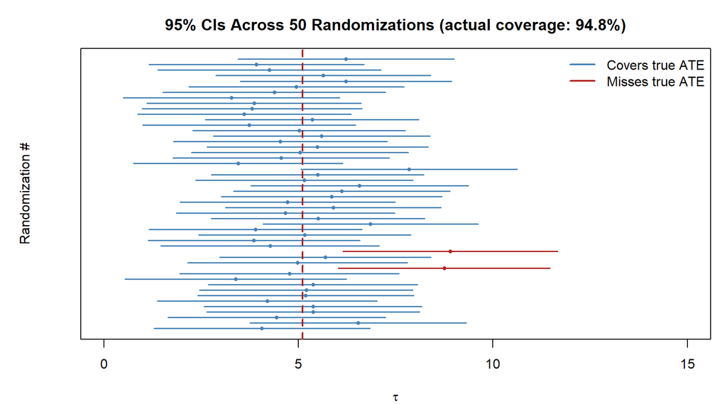

```r
# ----- Using the same heterogeneous-effects population -----
# Compute 95% CIs across many randomizations, check how often they cover tau

covers <- logical(n_sims)

for (s in 1:n_sims) {
  idx_t <- sample(1:N, n1)
  Z <- rep(0, N); Z[idx_t] <- 1
  Y_obs <- ifelse(Z == 1, Y1_pop, Y0_pop)

  tau_hat <- mean(Y_obs[Z == 1]) - mean(Y_obs[Z == 0])
  se_hat <- sqrt(var(Y_obs[Z == 1]) / n1 + var(Y_obs[Z == 0]) / n0)

  ci_lo <- tau_hat - 1.96 * se_hat
  ci_hi <- tau_hat + 1.96 * se_hat

  covers[s] <- (true_ate >= ci_lo) & (true_ate <= ci_hi)
}

coverage <- mean(covers)

# ----- Visual: show first 50 CIs, color by whether they cover -----
par(mar = c(4, 5, 3, 1))
show_n <- 50
plot(NA, xlim = c(0, 15), ylim = c(1, show_n), yaxt = "n",
     xlab = expression(tau), ylab = "Randomization #",
     main = paste0("95% CIs Across 50 Randomizations (actual coverage: ",
                   round(coverage * 100, 1), "%)"))

for (s in 1:show_n) {
  idx_t <- sample(1:N, n1)
  Z <- rep(0, N); Z[idx_t] <- 1
  Y_obs <- ifelse(Z == 1, Y1_pop, Y0_pop)
  tau_hat <- mean(Y_obs[Z == 1]) - mean(Y_obs[Z == 0])
  se_hat <- sqrt(var(Y_obs[Z == 1]) / n1 + var(Y_obs[Z == 0]) / n0)
  ci_lo <- tau_hat - 1.96 * se_hat
  ci_hi <- tau_hat + 1.96 * se_hat
  hit <- (true_ate >= ci_lo) & (true_ate <= ci_hi)

  segments(ci_lo, s, ci_hi, s, col = ifelse(hit, "steelblue", "firebrick"), lwd = 1.5)
  points(tau_hat, s, pch = 16, cex = 0.6, col = ifelse(hit, "steelblue", "firebrick"))
}
abline(v = true_ate, col = "firebrick", lwd = 2, lty = 2)
legend("topright", legend = c("Covers true ATE", "Misses true ATE"),
       col = c("steelblue", "firebrick"), lwd = 2, bty = "n")
```

# 5. FWL Theorem: What Regression Actually Does

Regression strips out the part of Z explained by X, then relates the leftover to Y. This visualizes the residualization.

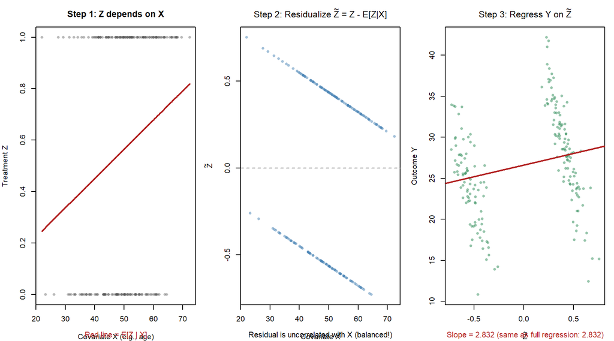

```r
# ----- Generate observational data with a confounder -----
n <- 200
X <- rnorm(n, 50, 10)                    # covariate (e.g., age)
Z <- rbinom(n, 1, plogis(-2 + 0.04 * X)) # treatment depends on X
Y <- 3 * Z + 0.5 * X + rnorm(n, 0, 3)   # outcome depends on both

# ----- FWL step 1: regress Z on X, get residuals -----
Z_on_X <- lm(Z ~ X)
Z_tilde <- resid(Z_on_X)  # the part of Z that X can't explain

# ----- FWL step 2: regress Y on Z_tilde -----
fwl_fit <- lm(Y ~ Z_tilde)
tau_fwl <- coef(fwl_fit)["Z_tilde"]

# compare to full regression
full_fit <- lm(Y ~ Z + X)
tau_full <- coef(full_fit)["Z"]

# ----- Plot -----
par(mfrow = c(1, 3), mar = c(4, 4, 3, 1))

# Panel 1: Z vs X -- treatment assignment depends on the covariate
plot(X, Z, pch = 16, col = adjustcolor("gray30", 0.4), cex = 0.8,
     main = "Step 1: Z depends on X",
     xlab = "Covariate X (e.g., age)", ylab = "Treatment Z")
lines(sort(X), fitted(Z_on_X)[order(X)], col = "firebrick", lwd = 2)
mtext("Red line = E[Z | X]", side = 1, line = 2.8, cex = 0.7, col = "firebrick")

# Panel 2: Z_tilde -- the residual (part X can't explain)
plot(X, Z_tilde, pch = 16, col = adjustcolor("steelblue", 0.5), cex = 0.8,
     main = expression("Step 2: Residualize " * tilde(Z) * " = Z - E[Z|X]"),
     xlab = "Covariate X", ylab = expression(tilde(Z)))
abline(h = 0, lty = 2, col = "gray50")
mtext("Residual is uncorrelated with X (balanced!)", side = 1, line = 2.8, cex = 0.7)

# Panel 3: Y vs Z_tilde -- the FWL regression
plot(Z_tilde, Y, pch = 16, col = adjustcolor("seagreen", 0.5), cex = 0.8,
     main = expression("Step 3: Regress Y on " * tilde(Z)),
     xlab = expression(tilde(Z)), ylab = "Outcome Y")
abline(fwl_fit, col = "firebrick", lwd = 2)
mtext(paste0("Slope = ", round(tau_fwl, 3), " (same as full regression: ",
             round(tau_full, 3), ")"),
      side = 1, line = 2.8, cex = 0.7, col = "firebrick")
```

**Takeaway:** Panel 2 is the key insight – after residualizing, the “treatment residual” is uncorrelated with X. Regression has stripped out the confounder. The slope in Panel 3 IS the regression coefficient on Z from the full model.

# 6. Misspecification Bias: When Regression Gets It Wrong

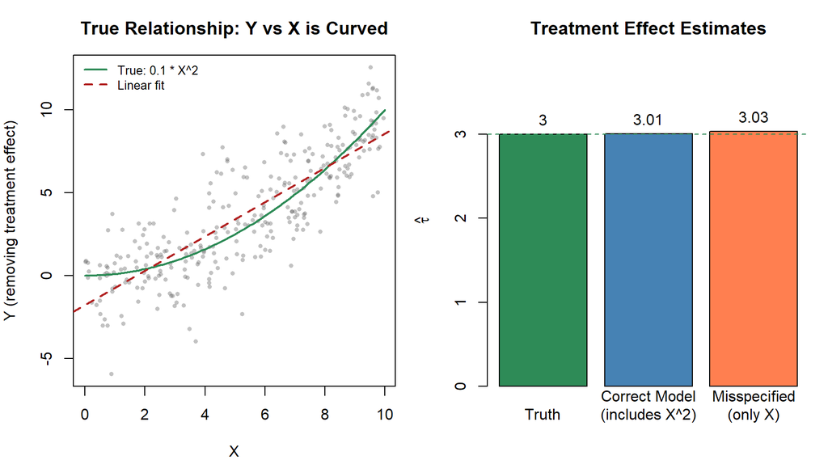

```r
# ----- Data where the TRUE relationship is quadratic -----
n <- 300
X <- runif(n, 0, 10)
Z <- rbinom(n, 1, plogis(-1 + 0.2 * X))  # treatment depends on X
# TRUE model: Y depends on X^2 (nonlinear!), but we only put X in the regression
Y <- 3 * Z + 0.1 * X^2 + rnorm(n, 0, 2)

# --- Correct model (includes X^2) ---
correct_fit <- lm(Y ~ Z + X + I(X^2))
tau_correct <- coef(correct_fit)["Z"]

# --- Misspecified model (only includes X, not X^2) ---
wrong_fit <- lm(Y ~ Z + X)
tau_wrong <- coef(wrong_fit)["Z"]

# ----- Plot -----
par(mfrow = c(1, 2), mar = c(4, 4, 3, 1))

# Panel 1: the true relationship is curved
plot(X, Y - 3 * Z, pch = 16, col = adjustcolor("gray40", 0.4), cex = 0.6,
     main = "True Relationship: Y vs X is Curved",
     xlab = "X", ylab = "Y (removing treatment effect)")
# overlay the linear fit vs the truth
curve(0.1 * x^2, from = 0, to = 10, add = TRUE, col = "seagreen", lwd = 2)
abline(lm((Y - 3 * Z) ~ X), col = "firebrick", lwd = 2, lty = 2)
legend("topleft", legend = c("True: 0.1 * X^2", "Linear fit"),
       col = c("seagreen", "firebrick"), lwd = 2, lty = c(1, 2), bty = "n", cex = 0.8)

# Panel 2: how estimates compare
ests_compare <- c(3, tau_correct, tau_wrong)
names(ests_compare) <- c("Truth", "Correct Model\n(includes X^2)", "Misspecified\n(only X)")
bp <- barplot(ests_compare, col = c("seagreen", "steelblue", "coral"),
        main = "Treatment Effect Estimates",
        ylab = expression(hat(tau)), ylim = c(0, max(ests_compare) * 1.3))
text(bp, ests_compare, labels = round(ests_compare, 2), pos = 3)
abline(h = 3, lty = 2, col = "seagreen")
```

# 7. Randomization Balances EVERYTHING

In a randomized experiment, treated and control groups are balanced on ALL covariates (observed and unobserved, linear and nonlinear).

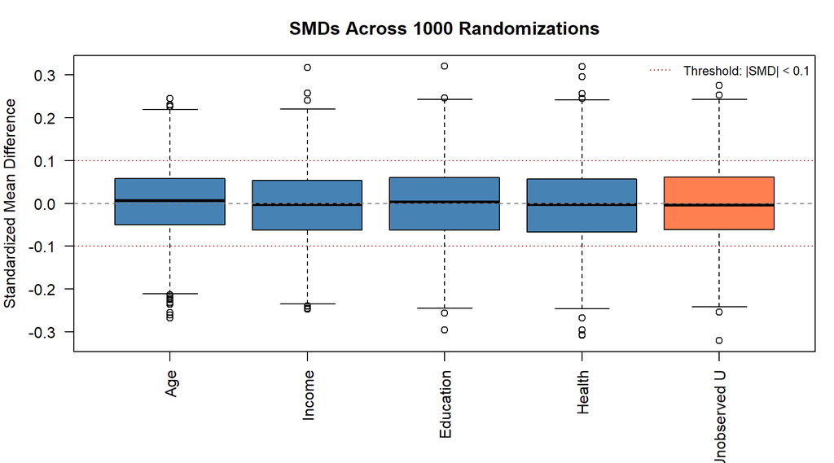

```r
# ----- Population of 500 people with many covariates -----
N <- 500
n1 <- 250
pop <- data.frame(
  age      = rnorm(N, 40, 12),
  income   = rnorm(N, 60000, 20000),
  educ     = rpois(N, 14),
  health   = rbeta(N, 5, 2) * 100,
  secret_U = rnorm(N, 0, 1)  # UNOBSERVED confounder
)

# ----- Compute SMDs across 1000 randomizations -----
n_sims <- 1000
smd_mat <- matrix(NA, n_sims, 5)
colnames(smd_mat) <- c("Age", "Income", "Education", "Health", "Unobserved U")

for (s in 1:n_sims) {
  Z <- rep(0, N); Z[sample(1:N, n1)] <- 1
  for (j in 1:5) {
    x <- pop[, j]
    x_t <- x[Z == 1]; x_c <- x[Z == 0]
    # SMD = (mean_T - mean_C) / pooled_SD
    pooled_sd <- sqrt((var(x_t) + var(x_c)) / 2)
    smd_mat[s, j] <- (mean(x_t) - mean(x_c)) / pooled_sd
  }
}

# ----- Boxplot of SMDs -----
par(mar = c(6, 4, 3, 1))
boxplot(smd_mat, col = c(rep("steelblue", 4), "coral"),
        main = "SMDs Across 1000 Randomizations",
        ylab = "Standardized Mean Difference", las = 2)
abline(h = 0, lty = 2, col = "gray50")
abline(h = c(-0.1, 0.1), lty = 3, col = "firebrick")
legend("topright", legend = c("Threshold: |SMD| < 0.1"),
       lty = 3, col = "firebrick", bty = "n", cex = 0.8)
```

**Takeaway:** ALL covariates – including the unobserved one (coral) – are tightly centered around SMD = 0. Randomization balances things you cannot see. No other method can do this.

# 8. Fisher’s Randomization Test

Under the sharp null (treatment does nothing), we can compute the test statistic for every possible randomization and see where our observed statistic falls.

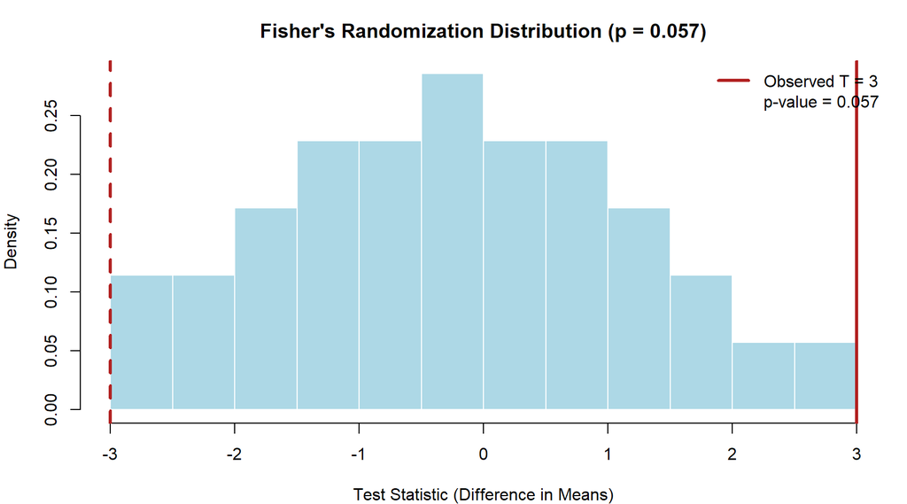

```r
# ----- Small experiment: 8 people, 4 treated -----
Y_obs <- c(8, 6, 7, 9, 4, 6, 5, 3)  # observed outcomes
N <- 8; n1 <- 4

# Observed assignment: first 4 are treated
Z_obs <- c(1, 1, 1, 1, 0, 0, 0, 0)
T_obs <- mean(Y_obs[Z_obs == 1]) - mean(Y_obs[Z_obs == 0])

# Under sharp null: outcomes don't change regardless of assignment
# Enumerate all choose(8,4) = 70 possible assignments
combos <- combn(1:N, n1)
T_all <- apply(combos, 2, function(idx) {
  mean(Y_obs[idx]) - mean(Y_obs[-idx])
})

# p-value = fraction with |T| >= |T_obs|
p_value <- mean(abs(T_all) >= abs(T_obs))

# ----- Histogram of the randomization distribution -----
par(mar = c(4, 4, 3, 1))
hist(T_all, breaks = 20, col = "lightblue", border = "white",
     main = paste0("Fisher's Randomization Distribution (p = ", round(p_value, 3), ")"),
     xlab = "Test Statistic (Difference in Means)", probability = TRUE)
abline(v = T_obs, col = "firebrick", lwd = 3)
abline(v = -T_obs, col = "firebrick", lwd = 3, lty = 2)
legend("topright",
       legend = c(paste("Observed T =", round(T_obs, 2)),
                  paste("p-value =", round(p_value, 3))),
       col = c("firebrick", NA), lwd = c(3, NA), bty = "n")
```

**Takeaway:** Under the sharp null, we know every possible value of the test statistic. The red line is what we actually observed. The p-value is the fraction of the histogram at or beyond the red lines. No assumptions about normality needed.

# 9. Selection Bias in Observational Studies

When treatment is not randomized, naive comparison = causal effect + selection bias.

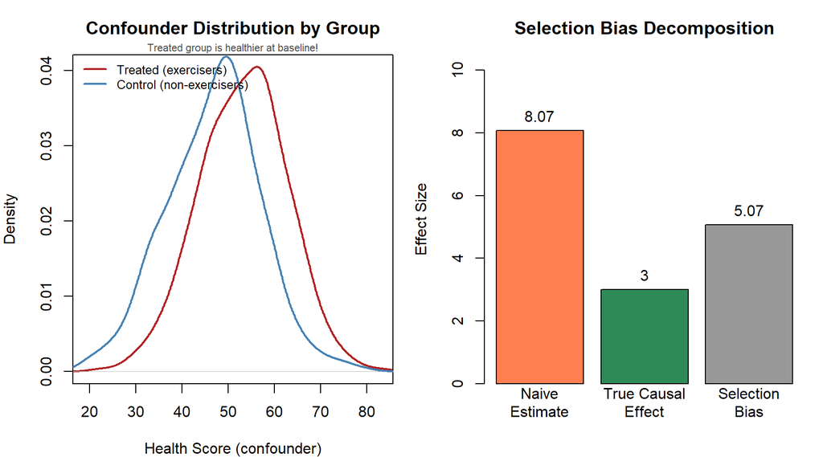

```r
# ----- Generate observational data with selection bias -----
N <- 1000
# health is a confounder: healthier people exercise more AND have better outcomes
health <- rnorm(N, 50, 10)
# treatment (exercise) depends on health
Z <- rbinom(N, 1, plogis(-3 + 0.06 * health))
# potential outcomes: baseline depends on health
Y0 <- 0.8 * health + rnorm(N, 0, 5)  # outcome without exercise
Y1 <- Y0 + 3                          # TRUE effect = exactly 3 for everyone
Y_obs <- ifelse(Z == 1, Y1, Y0)

naive_est <- mean(Y_obs[Z == 1]) - mean(Y_obs[Z == 0])
true_effect <- 3
selection_bias <- naive_est - true_effect

# ----- Visualize -----
par(mfrow = c(1, 2), mar = c(4, 4, 3, 1))

# Panel 1: covariate distributions show treated are healthier
plot(density(health[Z == 1]), col = "firebrick", lwd = 2, xlim = range(health),
     main = "Confounder Distribution by Group",
     xlab = "Health Score (confounder)")
lines(density(health[Z == 0]), col = "steelblue", lwd = 2)
legend("topleft", legend = c("Treated (exercisers)", "Control (non-exercisers)"),
       col = c("firebrick", "steelblue"), lwd = 2, bty = "n", cex = 0.8)
mtext("Treated group is healthier at baseline!", cex = 0.7, col = "gray30")

# Panel 2: decomposition
vals <- c(naive_est, true_effect, selection_bias)
names(vals) <- c("Naive\nEstimate", "True Causal\nEffect", "Selection\nBias")
bp <- barplot(vals, col = c("coral", "seagreen", "gray60"),
        main = "Selection Bias Decomposition",
        ylab = "Effect Size", ylim = c(0, max(vals) * 1.3))
text(bp, vals, labels = round(vals, 2), pos = 3)
```

**Takeaway:** The naive estimate (coral) is inflated because exercisers were already healthier. The true causal effect is 3 (green), but we see ~8.1 because of selection bias (gray). This is why you need the methods from this class.

# 10. Propensity Score: Collapsing All Covariates to One Number

The propensity score $e(X) = \Pr(Z=1|X)$ compresses all covariates into one dimension. Matching on this one number achieves balance on everything.

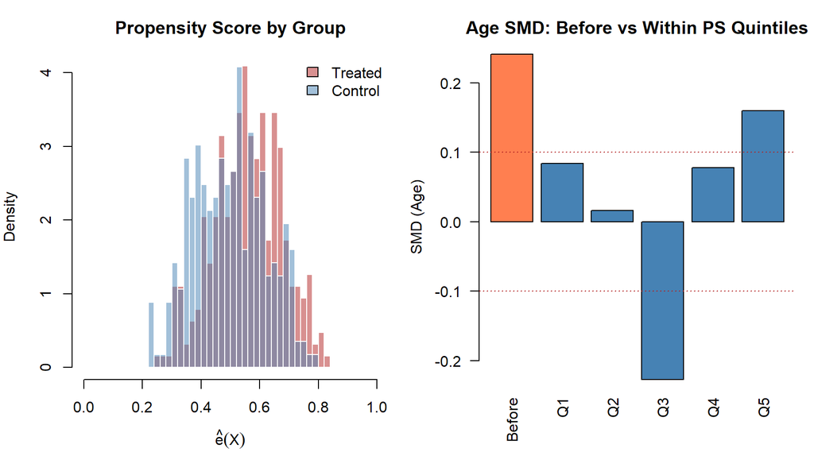

```r
# ----- Observational data with 3 covariates -----
N <- 600
age  <- rnorm(N, 45, 10)
male <- rbinom(N, 1, 0.5)
inc  <- rnorm(N, 50000, 15000)

# treatment probability depends on all three
lp <- -3 + 0.04 * age + 0.5 * male + 0.00002 * inc
Z <- rbinom(N, 1, plogis(lp))

# fit propensity score model
ps_model <- glm(Z ~ age + male + inc, family = binomial)
ps <- fitted(ps_model)

# ----- Plot propensity score distributions -----
par(mfrow = c(1, 2), mar = c(4, 4, 3, 1))

# Panel 1: PS histograms by group
hist(ps[Z == 1], breaks = 25, col = adjustcolor("firebrick", 0.5),
     border = "white", probability = TRUE, xlim = c(0, 1),
     main = "Propensity Score by Group",
     xlab = expression(hat(e)(X)))
hist(ps[Z == 0], breaks = 25, col = adjustcolor("steelblue", 0.5),
     border = "white", probability = TRUE, add = TRUE)
legend("topright", legend = c("Treated", "Control"),
       fill = adjustcolor(c("firebrick", "steelblue"), 0.5), bty = "n")

# Panel 2: checking balance within PS strata
# divide into 5 quintiles and check age balance within each
ps_quintile <- cut(ps, breaks = quantile(ps, probs = 0:5 / 5), include.lowest = TRUE)
q_labels <- levels(ps_quintile)

smd_before <- (mean(age[Z == 1]) - mean(age[Z == 0])) / sqrt((var(age[Z == 1]) + var(age[Z == 0])) / 2)
smd_within <- sapply(levels(ps_quintile), function(q) {
  idx <- ps_quintile == q
  if (sum(Z[idx] == 1) > 1 & sum(Z[idx] == 0) > 1) {
    a_t <- age[idx & Z == 1]; a_c <- age[idx & Z == 0]
    (mean(a_t) - mean(a_c)) / sqrt((var(a_t) + var(a_c)) / 2)
  } else NA
})

barplot(c(smd_before, smd_within), col = c("coral", rep("steelblue", 5)),
        main = "Age SMD: Before vs Within PS Quintiles",
        ylab = "SMD (Age)", names.arg = c("Before", paste0("Q", 1:5)),
        las = 2)
abline(h = c(-0.1, 0.1), lty = 3, col = "firebrick")
```

# 11. Matching: Finding Comparable People

Matching pairs each treated person with a similar control. Good matches = low bias.

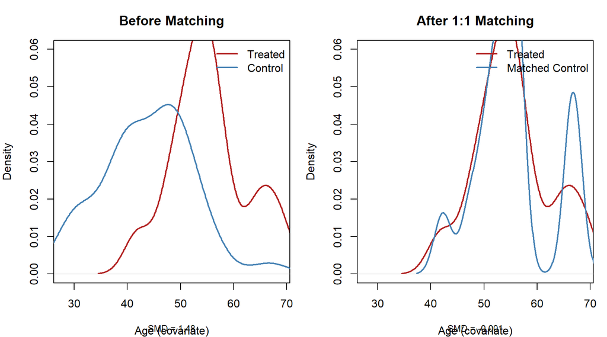

```r
# ----- Simple 1D matching example -----
n_t <- 15; n_c <- 40
X_t <- rnorm(n_t, 55, 8)   # treated people tend to be older
X_c <- rnorm(n_c, 45, 8)   # control people tend to be younger

# ----- Nearest-neighbor matching -----
matched_c <- numeric(n_t)
for (i in 1:n_t) {
  dists <- abs(X_c - X_t[i])
  matched_c[i] <- which.min(dists)
}
X_c_matched <- X_c[matched_c]

# ----- Plot -----
par(mfrow = c(1, 2), mar = c(4, 4, 3, 1))

# Panel 1: Before matching -- distributions differ
plot(density(X_t), col = "firebrick", lwd = 2, xlim = range(c(X_t, X_c)),
     main = "Before Matching", xlab = "Age (covariate)", ylim = c(0, 0.06))
lines(density(X_c), col = "steelblue", lwd = 2)
legend("topright", legend = c("Treated", "Control"),
       col = c("firebrick", "steelblue"), lwd = 2, bty = "n")
smd_before <- (mean(X_t) - mean(X_c)) / sqrt((var(X_t) + var(X_c)) / 2)
mtext(paste("SMD =", round(smd_before, 3)), side = 1, line = 2.8, cex = 0.8)

# Panel 2: After matching -- distributions overlap
plot(density(X_t), col = "firebrick", lwd = 2, xlim = range(c(X_t, X_c)),
     main = "After 1:1 Matching", xlab = "Age (covariate)", ylim = c(0, 0.06))
lines(density(X_c_matched), col = "steelblue", lwd = 2)
legend("topright", legend = c("Treated", "Matched Control"),
       col = c("firebrick", "steelblue"), lwd = 2, bty = "n")
smd_after <- (mean(X_t) - mean(X_c_matched)) / sqrt((var(X_t) + var(X_c_matched)) / 2)
mtext(paste("SMD =", round(smd_after, 3)), side = 1, line = 2.8, cex = 0.8)
```

**Takeaway:** Before matching, the age distributions are shifted apart (large SMD). After matching, they overlap closely (SMD near 0). Matching created comparable groups.

# 12. Love Plot: The Balance Diagnostic

Show SMDs for all covariates, before and after matching. This is THE diagnostic.

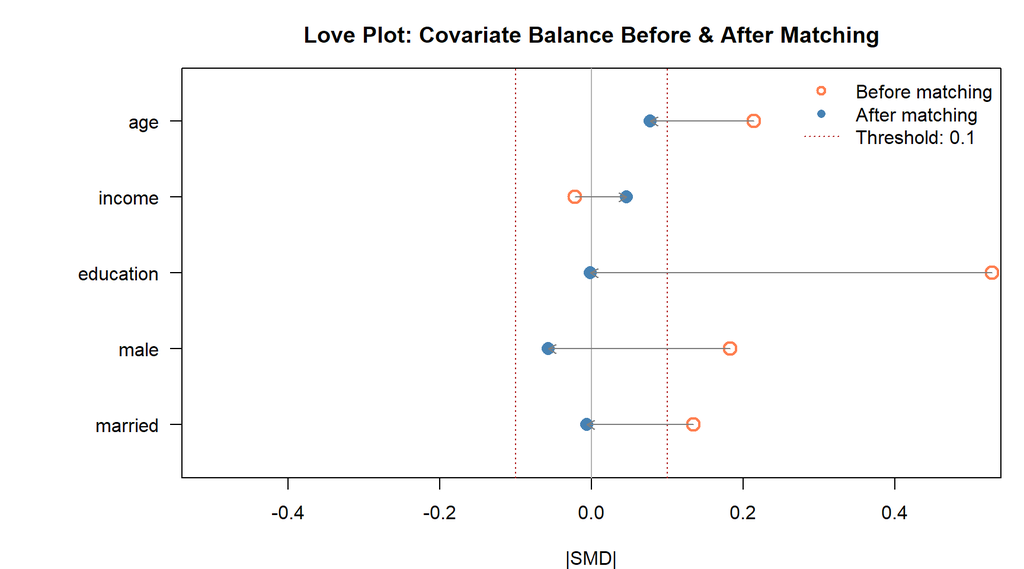

```r
# ----- Generate multi-covariate observational data -----
N <- 500
covs <- data.frame(
  age       = rnorm(N, 50, 10),
  income    = rnorm(N, 55000, 15000),
  education = rpois(N, 14),
  male      = rbinom(N, 1, 0.5),
  married   = rbinom(N, 1, 0.6)
)

# treatment depends on covariates
lp <- -2 + 0.03 * covs$age - 0.00001 * covs$income + 0.1 * covs$education +
      0.3 * covs$male + 0.2 * covs$married
Z <- rbinom(N, 1, plogis(lp))

# compute SMDs before matching
smd_before <- sapply(covs, function(x) {
  (mean(x[Z == 1]) - mean(x[Z == 0])) / sqrt((var(x[Z == 1]) + var(x[Z == 0])) / 2)
})

# simulate "after matching" -- apply PS matching via nearest-neighbor on PS
ps <- fitted(glm(Z ~ ., data = cbind(covs, Z = Z), family = binomial))
# simple NN match on PS
matched_c <- numeric(sum(Z == 1))
t_idx <- which(Z == 1)
c_idx <- which(Z == 0)
for (i in seq_along(t_idx)) {
  dists <- abs(ps[c_idx] - ps[t_idx[i]])
  matched_c[i] <- c_idx[which.min(dists)]
}
# SMDs after
smd_after <- sapply(covs, function(x) {
  (mean(x[t_idx]) - mean(x[matched_c])) /
    sqrt((var(x[t_idx]) + var(x[matched_c])) / 2)
})

# ----- Love Plot -----
par(mar = c(4, 8, 3, 1))
k <- length(smd_before)
y_pos <- k:1

plot(NA, xlim = c(-0.5, 0.5), ylim = c(0.5, k + 0.5),
     yaxt = "n", xlab = "|SMD|", ylab = "",
     main = "Love Plot: Covariate Balance Before & After Matching")
axis(2, at = y_pos, labels = names(smd_before), las = 1)
abline(v = 0, lty = 1, col = "gray70")
abline(v = c(-0.1, 0.1), lty = 3, col = "firebrick")

# before: open circles
points(smd_before, y_pos, pch = 1, col = "coral", cex = 1.5, lwd = 2)
# after: filled circles
points(smd_after, y_pos, pch = 16, col = "steelblue", cex = 1.5)
# arrows showing improvement
arrows(smd_before, y_pos, smd_after, y_pos, length = 0.08, col = "gray50")

legend("topright", legend = c("Before matching", "After matching", "Threshold: 0.1"),
       pch = c(1, 16, NA), col = c("coral", "steelblue", "firebrick"),
       lty = c(NA, NA, 3), pt.lwd = c(2, 1, NA), bty = "n")
```

# 13. IPW: How Reweighting Creates Balance

IPW gives large weights to “rare” people – those unlikely to be in the group they ended up in. This makes the weighted groups look like the overall population.

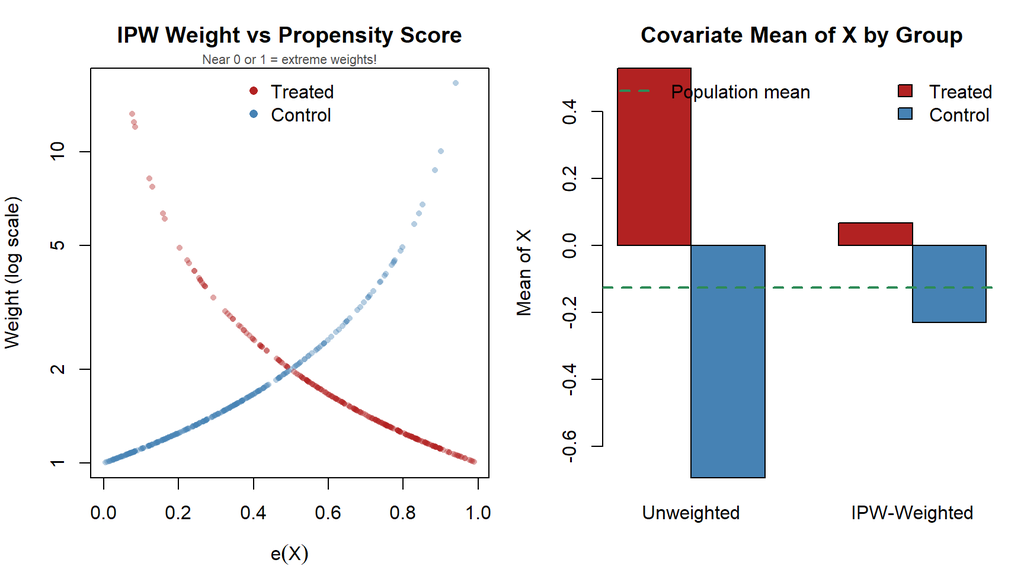

```r
# ----- Illustrate IPW weights -----
N <- 500
X <- rnorm(N, 0, 1)
ps_true <- plogis(1.5 * X)  # propensity depends on X
Z <- rbinom(N, 1, ps_true)

# IPW weights
w <- ifelse(Z == 1, 1 / ps_true, 1 / (1 - ps_true))

# ----- Plot -----
par(mfrow = c(1, 2), mar = c(4, 4, 3, 1))

# Panel 1: PS vs weight -- shows how extreme PS = extreme weight
plot(ps_true, w, pch = 16, col = adjustcolor(ifelse(Z == 1, "firebrick", "steelblue"), 0.4),
     cex = 0.7, log = "y",
     main = "IPW Weight vs Propensity Score",
     xlab = expression(e(X)), ylab = "Weight (log scale)")
legend("top", legend = c("Treated", "Control"),
       col = c("firebrick", "steelblue"), pch = 16, bty = "n")
mtext("Near 0 or 1 = extreme weights!", cex = 0.7, col = "gray30")

# Panel 2: balance before and after weighting
# unweighted means by group
mean_x_t_raw <- mean(X[Z == 1])
mean_x_c_raw <- mean(X[Z == 0])

# IPW-weighted means
mean_x_t_ipw <- sum(Z * X / ps_true) / sum(Z / ps_true)
mean_x_c_ipw <- sum((1 - Z) * X / (1 - ps_true)) / sum((1 - Z) / (1 - ps_true))

vals <- matrix(c(mean_x_t_raw, mean_x_c_raw, mean_x_t_ipw, mean_x_c_ipw),
               nrow = 2, dimnames = list(c("Treated", "Control"), c("Unweighted", "IPW-Weighted")))
barplot(vals, beside = TRUE, col = c("firebrick", "steelblue"),
        main = "Covariate Mean of X by Group",
        ylab = "Mean of X")
legend("topright", legend = c("Treated", "Control"),
       fill = c("firebrick", "steelblue"), bty = "n")
abline(h = mean(X), lty = 2, col = "seagreen", lwd = 2)
legend("topleft", legend = "Population mean", lty = 2, col = "seagreen", lwd = 2, bty = "n")
```

# 14. Extreme Weights: Why Overlap Matters

When propensity scores are near 0 or 1, IPW becomes unstable. A handful of people dominate the entire estimate.

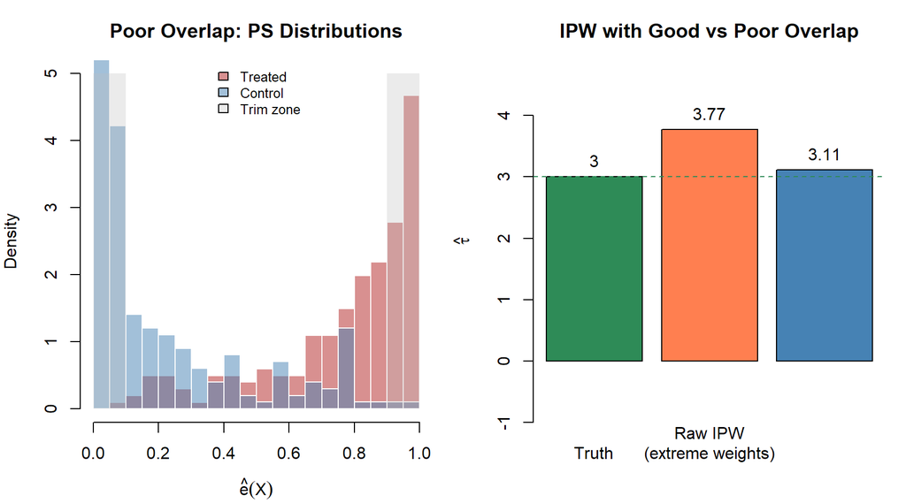

```r
# ----- Simulate poor overlap -----
N <- 400
X <- c(rnorm(200, -1, 0.8), rnorm(200, 1, 0.8))  # two clusters
ps_true <- plogis(2 * X)  # strong separation
Z <- rbinom(N, 1, ps_true)
Y0 <- 2 * X + rnorm(N, 0, 2)
Y1 <- Y0 + 3
Y <- ifelse(Z == 1, Y1, Y0)

# raw IPW estimate
ipw_raw <- mean(Z * Y / ps_true - (1 - Z) * Y / (1 - ps_true))

# trimmed IPW: drop units with extreme PS
keep <- ps_true > 0.1 & ps_true < 0.9
ipw_trimmed <- mean(Z[keep] * Y[keep] / ps_true[keep] -
                    (1 - Z[keep]) * Y[keep] / (1 - ps_true[keep]))

# ----- Plots -----
par(mfrow = c(1, 2), mar = c(4, 4, 3, 1))

# Panel 1: PS histogram showing poor overlap
hist(ps_true[Z == 1], breaks = 30, col = adjustcolor("firebrick", 0.5),
     border = "white", probability = TRUE, xlim = c(0, 1),
     main = "Poor Overlap: PS Distributions",
     xlab = expression(hat(e)(X)), ylim = c(0, 5))
hist(ps_true[Z == 0], breaks = 30, col = adjustcolor("steelblue", 0.5),
     border = "white", probability = TRUE, add = TRUE)
# trimming region
rect(0, 0, 0.1, 5, col = adjustcolor("gray", 0.3), border = NA)
rect(0.9, 0, 1, 5, col = adjustcolor("gray", 0.3), border = NA)
legend("top", legend = c("Treated", "Control", "Trim zone"),
       fill = c(adjustcolor("firebrick", 0.5), adjustcolor("steelblue", 0.5),
                adjustcolor("gray", 0.3)), bty = "n", cex = 0.8)

# Panel 2: estimates comparison
vals <- c(3, ipw_raw, ipw_trimmed)
names(vals) <- c("Truth", "Raw IPW\n(extreme weights)", "Trimmed IPW\n(0.1 < PS < 0.9)")
bp <- barplot(vals, col = c("seagreen", "coral", "steelblue"),
        main = "IPW with Good vs Poor Overlap",
        ylab = expression(hat(tau)), ylim = c(min(0, min(vals)) - 1, max(vals) * 1.3))
text(bp, vals, labels = round(vals, 2), pos = 3)
abline(h = 3, lty = 2, col = "seagreen")
```

**Takeaway:** With poor overlap (left panel, groups barely overlap), raw IPW (coral) can be wildly off because a few extreme-weight people dominate. Trimming to the overlap region (blue) gives a much more stable estimate. The gray zones are where we trim.

# 15. AIPW: The Self-Correcting Estimator

AIPW combines outcome regression with IPW correction. If either model is right, you get the right answer.

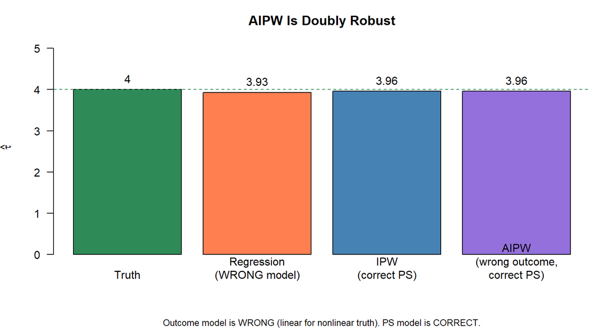

```r
# ----- Compare three estimators under different misspecification scenarios -----
N <- 800
X <- rnorm(N, 0, 1)
ps_true <- plogis(0.5 * X)
Z <- rbinom(N, 1, ps_true)
Y0 <- 2 + 3 * X + 0.5 * X^2 + rnorm(N, 0, 2)  # nonlinear outcome model
Y1 <- Y0 + 4
Y <- ifelse(Z == 1, Y1, Y0)
true_ate <- 4

# --- Scenario: outcome model WRONG (linear), PS model CORRECT ---
ps_correct <- fitted(glm(Z ~ X, family = binomial))
# wrong outcome model (linear only)
mu1_wrong <- predict(lm(Y ~ X, data = data.frame(Y = Y, X = X), subset = Z == 1),
                     newdata = data.frame(X = X))
mu0_wrong <- predict(lm(Y ~ X, data = data.frame(Y = Y, X = X), subset = Z == 0),
                     newdata = data.frame(X = X))

# IPW with correct PS
ipw_est <- mean(Z * Y / ps_correct - (1 - Z) * Y / (1 - ps_correct))

# Regression only (wrong model)
reg_est <- mean(mu1_wrong - mu0_wrong)

# AIPW: wrong outcome + correct PS
aipw_est <- mean(mu1_wrong - mu0_wrong +
                 Z * (Y - mu1_wrong) / ps_correct -
                 (1 - Z) * (Y - mu0_wrong) / (1 - ps_correct))

# ----- Plot -----
par(mar = c(6, 4, 3, 1))
vals <- c(true_ate, reg_est, ipw_est, aipw_est)
names(vals) <- c("Truth", "Regression\n(WRONG model)", "IPW\n(correct PS)", "AIPW\n(wrong outcome,\ncorrect PS)")
bp <- barplot(vals, col = c("seagreen", "coral", "steelblue", "mediumpurple"),
        main = "AIPW Is Doubly Robust",
        ylab = expression(hat(tau)), ylim = c(0, max(vals) * 1.3), las = 1)
text(bp, vals, labels = round(vals, 2), pos = 3)
abline(h = true_ate, lty = 2, col = "seagreen")
mtext("Outcome model is WRONG (linear for nonlinear truth). PS model is CORRECT.",
      side = 1, line = 4.5, cex = 0.8)
```

# 16. The Extrapolation Problem

When treated and control occupy different covariate regions, regression extrapolates into data-free zones.

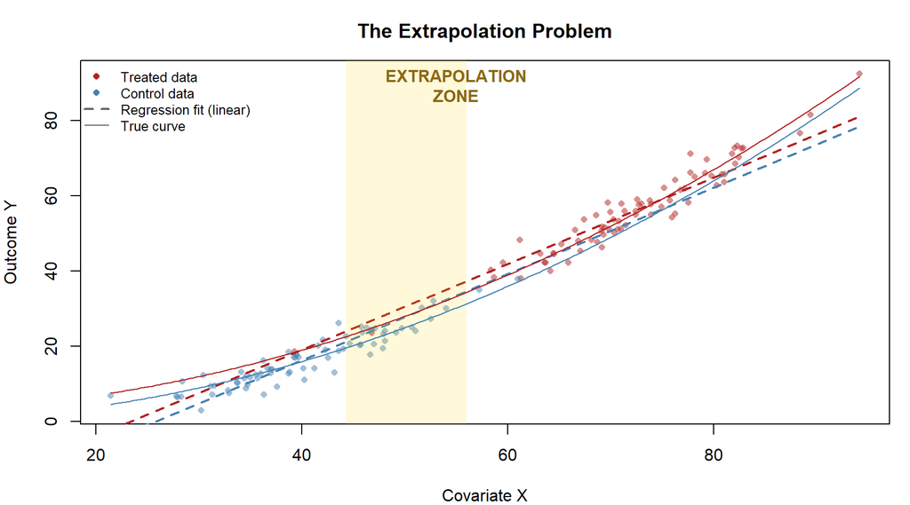

```r
# ----- Generate data with poor overlap -----
n <- 150
# treated people tend to have high X, controls tend to have low X
X_t <- rnorm(75, mean = 70, sd = 8)
X_c <- rnorm(75, mean = 40, sd = 8)
X <- c(X_t, X_c)
Z <- c(rep(1, 75), rep(0, 75))

# true outcome: NONLINEAR in X
Y <- 3 * Z + 0.01 * X^2 + rnorm(n, 0, 3)

# fit linear regression (will extrapolate across the gap)
fit <- lm(Y ~ Z + X)

# ----- Plot -----
par(mar = c(4, 4, 3, 1))
plot(X, Y, pch = 16, col = adjustcolor(ifelse(Z == 1, "firebrick", "steelblue"), 0.5),
     cex = 0.8, main = "The Extrapolation Problem",
     xlab = "Covariate X", ylab = "Outcome Y")

# add the regression lines for each group
x_seq <- seq(min(X), max(X), length = 200)
lines(x_seq, predict(fit, newdata = data.frame(Z = 1, X = x_seq)),
      col = "firebrick", lwd = 2, lty = 2)
lines(x_seq, predict(fit, newdata = data.frame(Z = 0, X = x_seq)),
      col = "steelblue", lwd = 2, lty = 2)

# highlight the gap region
rect(max(X_c) - 5, par("usr")[3], min(X_t) + 5, par("usr")[4],
     col = adjustcolor("gold", 0.15), border = NA)
text(55, max(Y) - 3, "EXTRAPOLATION\nZONE", col = "goldenrod4", cex = 1, font = 2)

# add true curves
lines(x_seq, 3 + 0.01 * x_seq^2, col = "firebrick", lwd = 1, lty = 1)
lines(x_seq, 0.01 * x_seq^2, col = "steelblue", lwd = 1, lty = 1)

legend("topleft",
       legend = c("Treated data", "Control data", "Regression fit (linear)", "True curve"),
       pch = c(16, 16, NA, NA), col = c("firebrick", "steelblue", "gray40", "gray40"),
       lty = c(NA, NA, 2, 1), lwd = c(NA, NA, 2, 1), bty = "n", cex = 0.8)
```

# 17. 1:1 vs 1:k Matching: Bias-Variance Trade-off

Using more controls per treated unit reduces variance but can increase bias because further matches are worse.

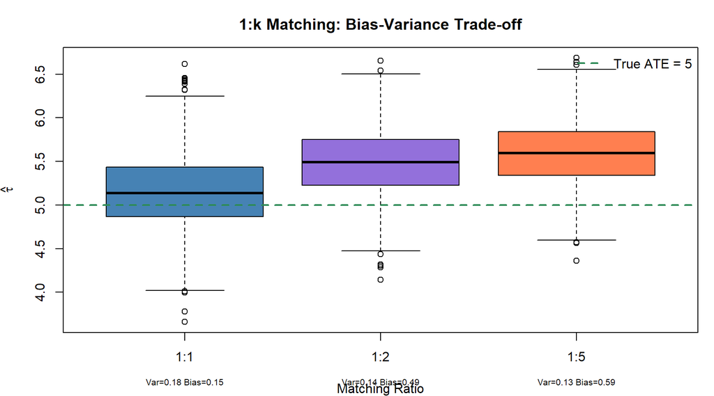

```r
# ----- Simulate the bias-variance trade-off -----
N_t <- 50; N_c <- 200
n_sims <- 2000

# population
X_t_pop <- rnorm(N_t, 55, 8)
X_c_pop <- rnorm(N_c, 45, 8)
Y_c_pop <- 0.5 * X_c_pop + rnorm(N_c, 0, 3)  # control outcomes

# for treated, true effect = 5
Y_t_pop <- 0.5 * X_t_pop + 5 + rnorm(N_t, 0, 3)

# function to do 1:k matching and estimate tau
match_1k <- function(k) {
  ests <- numeric(n_sims)
  for (s in 1:n_sims) {
    # resample treated
    t_idx <- sample(1:N_t, 30, replace = FALSE)
    X_t <- X_t_pop[t_idx]; Y_t <- Y_t_pop[t_idx]

    # for each treated, find k nearest controls
    matched_Y <- numeric(30)
    for (i in 1:30) {
      dists <- abs(X_c_pop - X_t[i])
      top_k <- order(dists)[1:k]
      matched_Y[i] <- mean(Y_c_pop[top_k])  # average k matched controls
    }
    ests[s] <- mean(Y_t - matched_Y)
  }
  return(ests)
}

est_1 <- match_1k(1)
est_2 <- match_1k(2)
est_5 <- match_1k(5)

# ----- Box plots -----
par(mar = c(4, 4, 3, 1))
boxplot(list("1:1" = est_1, "1:2" = est_2, "1:5" = est_5),
        col = c("steelblue", "mediumpurple", "coral"),
        main = "1:k Matching: Bias-Variance Trade-off",
        ylab = expression(hat(tau)),
        xlab = "Matching Ratio")
abline(h = 5, lty = 2, col = "seagreen", lwd = 2)
legend("topright", legend = "True ATE = 5", lty = 2, col = "seagreen", lwd = 2, bty = "n")

# add bias and variance annotations
for (i in 1:3) {
  ests_i <- list(est_1, est_2, est_5)[[i]]
  mtext(paste0("Var=", round(var(ests_i), 2), " Bias=", round(mean(ests_i) - 5, 2)),
        side = 1, at = i, line = 2.5, cex = 0.65)
}
```

**Takeaway:** 1:1 has the widest box (highest variance) but centers closest to 5. 1:5 has a tighter box (lower variance) but is pulled slightly away from 5 (more bias) because the 3rd-5th matches are worse. 1:2 is a common practical compromise. On the exam: `design = c(1,k)` in `kwaymatching()`.

# 18. Design vs Analysis: The Sacred Boundary

This shows the two-phase workflow. Design uses only X and Z. Analysis uses Y.

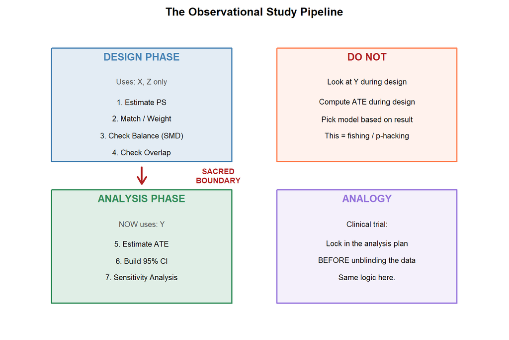

```r
# ----- Illustrate the pipeline -----
par(mar = c(1, 1, 2, 1))
plot(NA, xlim = c(0, 10), ylim = c(0, 10), xaxt = "n", yaxt = "n",
     xlab = "", ylab = "", main = "The Observational Study Pipeline", bty = "n")

# Design phase box
rect(0.5, 5.5, 4.5, 9.5, col = adjustcolor("steelblue", 0.15), border = "steelblue", lwd = 2)
text(2.5, 9.2, "DESIGN PHASE", font = 2, col = "steelblue", cex = 1.1)
text(2.5, 8.3, "Uses: X, Z only", cex = 0.8, col = "gray30")
text(2.5, 7.6, "1. Estimate PS", cex = 0.8, adj = 0.5)
text(2.5, 7.0, "2. Match / Weight", cex = 0.8)
text(2.5, 6.4, "3. Check Balance (SMD)", cex = 0.8)
text(2.5, 5.8, "4. Check Overlap", cex = 0.8)

# Arrow
arrows(2.5, 5.3, 2.5, 4.7, lwd = 3, col = "firebrick", length = 0.15)
text(4.2, 5.0, "SACRED\nBOUNDARY", col = "firebrick", font = 2, cex = 0.8)

# Analysis phase box
rect(0.5, 0.5, 4.5, 4.5, col = adjustcolor("seagreen", 0.15), border = "seagreen", lwd = 2)
text(2.5, 4.2, "ANALYSIS PHASE", font = 2, col = "seagreen", cex = 1.1)
text(2.5, 3.3, "NOW uses: Y", cex = 0.8, col = "gray30")
text(2.5, 2.6, "5. Estimate ATE", cex = 0.8)
text(2.5, 2.0, "6. Build 95% CI", cex = 0.8)
text(2.5, 1.4, "7. Sensitivity Analysis", cex = 0.8)

# Right side: what you CANNOT do
rect(5.5, 5.5, 9.5, 9.5, col = adjustcolor("coral", 0.1), border = "coral", lwd = 2)
text(7.5, 9.2, "DO NOT", font = 2, col = "firebrick", cex = 1.1)
text(7.5, 8.3, "Look at Y during design", cex = 0.8)
text(7.5, 7.6, "Compute ATE during design", cex = 0.8)
text(7.5, 7.0, "Pick model based on result", cex = 0.8)
text(7.5, 6.4, "This = fishing / p-hacking", cex = 0.8)

# Right side: analogy
rect(5.5, 0.5, 9.5, 4.5, col = adjustcolor("mediumpurple", 0.1), border = "mediumpurple", lwd = 2)
text(7.5, 4.2, "ANALOGY", font = 2, col = "mediumpurple", cex = 1.1)
text(7.5, 3.3, "Clinical trial:", cex = 0.8)
text(7.5, 2.6, "Lock in the analysis plan", cex = 0.8)
text(7.5, 2.0, "BEFORE unblinding the data", cex = 0.8)
text(7.5, 1.4, "Same logic here.", cex = 0.8)
```

**Takeaway:** The boundary between design and analysis is sacred. Everything above the red arrow uses ONLY covariates X and treatment Z. You commit to your comparison method before ever looking at outcomes Y. This prevents fishing.

# 19. Constant vs Heterogeneous Treatment Effects

When effects are constant, $S_\tau^2 = 0$ and the conservative variance is exact. When effects are heterogeneous, there is a gap.

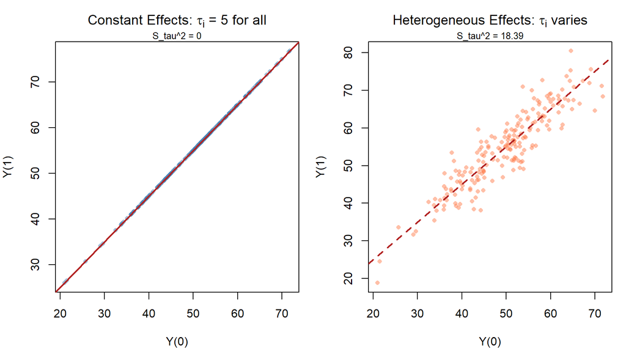

```r
N <- 200
Y0 <- rnorm(N, 50, 10)

par(mfrow = c(1, 2), mar = c(4, 4, 3, 1))

# ----- Constant effects: tau_i = 5 for all -----
Y1_const <- Y0 + 5
tau_const <- Y1_const - Y0
plot(Y0, Y1_const, pch = 16, col = adjustcolor("steelblue", 0.5), cex = 0.8,
     main = expression("Constant Effects: " * tau[i] * " = 5 for all"),
     xlab = "Y(0)", ylab = "Y(1)")
abline(a = 5, b = 1, col = "firebrick", lwd = 2)
mtext(paste("S_tau^2 =", round(var(tau_const), 4)), side = 3, line = 0, cex = 0.8)
# all points lie on a perfect line with slope 1 and intercept 5

# ----- Heterogeneous effects: tau_i varies -----
tau_hetero <- rnorm(N, 5, 4)
Y1_hetero <- Y0 + tau_hetero
plot(Y0, Y1_hetero, pch = 16, col = adjustcolor("coral", 0.5), cex = 0.8,
     main = expression("Heterogeneous Effects: " * tau[i] * " varies"),
     xlab = "Y(0)", ylab = "Y(1)")
abline(a = 5, b = 1, col = "firebrick", lwd = 2, lty = 2)
mtext(paste("S_tau^2 =", round(var(tau_hetero), 2)), side = 3, line = 0, cex = 0.8)
```

```r
# points scatter around the line because effects differ
```

**Takeaway:** Left: under constant effects, every person’s Y(1) is exactly 5 above their Y(0) – all points on the line. $S_\tau^2 = 0$, conservative estimator is exact. Right: with heterogeneous effects, points scatter around the line. $S_\tau^2 > 0$, conservative estimator overestimates the variance.

# 20. Summary: All Methods Need the Same Assumptions

Every method in this course relies on the same core assumptions. The methods differ in HOW they use those assumptions, not WHETHER they need them.

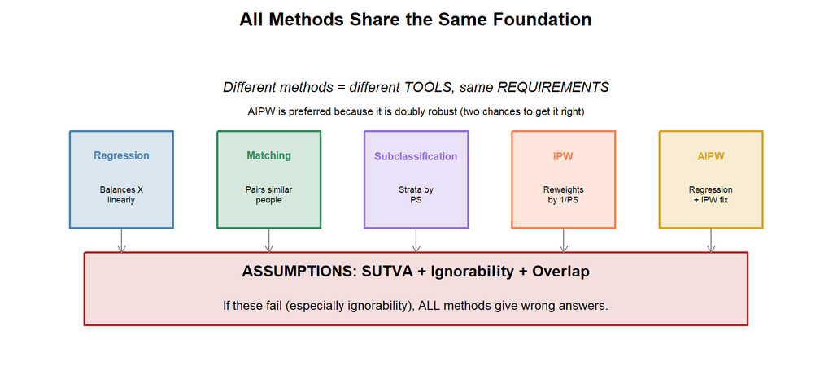

```r
par(mar = c(1, 1, 2, 1))
plot(NA, xlim = c(0, 10), ylim = c(0, 6), xaxt = "n", yaxt = "n",
     xlab = "", ylab = "", bty = "n",
     main = "All Methods Share the Same Foundation")

# Foundation
rect(0.5, 0.3, 9.5, 1.8, col = adjustcolor("firebrick", 0.15), border = "firebrick", lwd = 2)
text(5, 1.4, "ASSUMPTIONS: SUTVA + Ignorability + Overlap", font = 2, cex = 1)
text(5, 0.7, "If these fail (especially ignorability), ALL methods give wrong answers.", cex = 0.8)

# Methods built on top
methods <- c("Regression", "Matching", "Subclassification", "IPW", "AIPW")
colors <- c("steelblue", "seagreen", "mediumpurple", "coral", "goldenrod")
x_pos <- seq(1, 9, length = 5)
for (i in 1:5) {
  rect(x_pos[i] - 0.7, 2.3, x_pos[i] + 0.7, 4.3,
       col = adjustcolor(colors[i], 0.2), border = colors[i], lwd = 2)
  text(x_pos[i], 3.8, methods[i], font = 2, cex = 0.7, col = colors[i])
}
# lines connecting to foundation
for (i in 1:5) {
  arrows(x_pos[i], 2.3, x_pos[i], 1.8, length = 0.08, col = "gray50")
}

# labels inside method boxes
texts <- c("Balances X\nlinearly", "Pairs similar\npeople", "Strata by\nPS", "Reweights\nby 1/PS", "Regression\n+ IPW fix")
for (i in 1:5) {
  text(x_pos[i], 3.0, texts[i], cex = 0.55)
}

# Top note
text(5, 5.2, "Different methods = different TOOLS, same REQUIREMENTS", cex = 0.9, font = 3)
text(5, 4.7, "AIPW is preferred because it is doubly robust (two chances to get it right)", cex = 0.7)
```